# Written Assignment 03

Author

Owen Senowitz

Published

September 21, 2024

# Assignment Goal

The goal of this assignment is to demonstrate your understanding of exploratory data analysis. You may use any programming language of your choice. **R** and **Python** are the two popular languages for the **programmatic** data exploration.

# Assignment Specification

The first step is to identify a **relevant** open-source dataset. The dataset should have at least 500 instances and contain a mix of at least ten **continuous** and **categorical** variables. The next step is to perform various exploratory data analysis tasks discussed in the class. The final step is to summarize your findings. You may use Quarto/RMarkdown or Jupyter/Python to respond to this assignment. Use this document as a template to prepare your response.

Some open-source data sources for this assignment are the following. This list is not exhaustive and you are not required to select a datset from this list. If you come across other repositories of open source datasets, please post links on MS Teams for the benefit of other students.

1. Integrated Postsecondary Education Data System (IPEDS) is a system of 12 interrelated survey components conducted annually that gathers data from every college, university, and technical and vocational institution that participates in the federal student financial aid programs. [IPEDS Website](https://nces.ed.gov/ipeds/)
2. U.S. Securities and Exchange Commission (SEC) [Financial Statement Data Sets](https://www.sec.gov/dera/data/financial-statement-data-sets)
3. [United Nations (UN) Datasets](https://data.un.org/)
4. [World Bank Open Data](https://data.worldbank.org/)
5. [The Library of Congress Datasets](https://guides.loc.gov/datasets/repositories)
6. [NASDAQ Historical Datasets](https://www.nasdaq.com/market-activity/quotes/historical)
7. [The World Factbook](https://www.cia.gov/the-world-factbook/) and [Guide to Country Comparisons](https://www.cia.gov/the-world-factbook/references/guide-to-country-comparisons/)

# 1 The Data Quality Report

Document the data quality report in two separate tables, one for the continuous features and another for the categorical features. Use the table format discussed in the class.

## 1.1 Continuous Features

| Feature | Mean | Median | Standard Deviation | Minimum | Maximum | Missing Values |
| --- | --- | --- | --- | --- | --- | --- |
| Close/Last | 17.03 | 6.1883 | 25.84 | 0.4196 | 135.58 | 0 |
| Volume | 467196589.63 | 415380400.0 | 252617500.70 | 45645120 | 3688131600 | 0 |
| Open | 17.03 | 6.1948 | 25.86 | 0.4233 | 139.8 | 0 |
| High | 17.35 | 6.2695 | 26.37 | 0.4325 | 140.76 | 0 |
| Low | 16.68 | 6.0972 | 25.27 | 0.4193 | 132.42 | 0 |

## 1.2 Categorical Feature

| Feature | Unique Values | Missing Values | Most Frequent Value | Most Frequent Value Count |
| --- | --- | --- | --- | --- |
| Date | 2517 | 0 | 01/02/2015 | 1 |

# 2 Histograms of Continuous Features

Create a **histogram** for each continuous feature. What probability distributions the histograms reveal? For example, uniform, normal (unimodal), unimodal (skewed right), unimodal (skewed left), exponential, and multimodal.

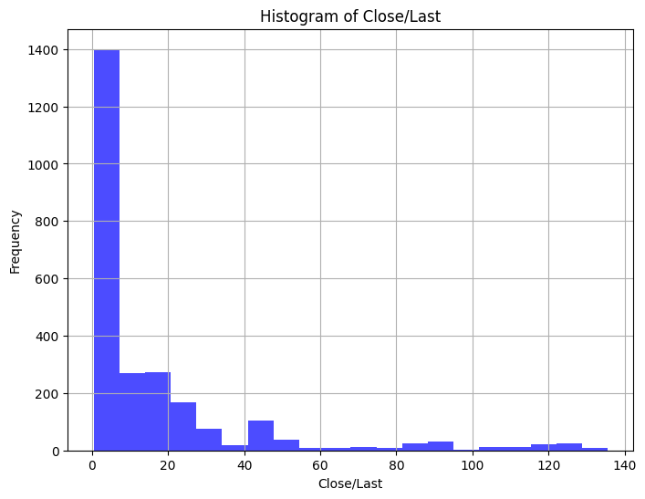

Skewed Right (Unimodal)

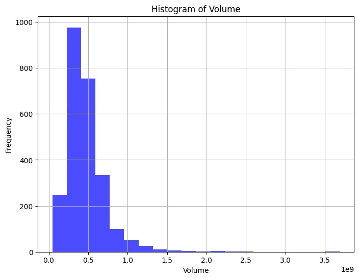

Skewed Right (Unimodal)

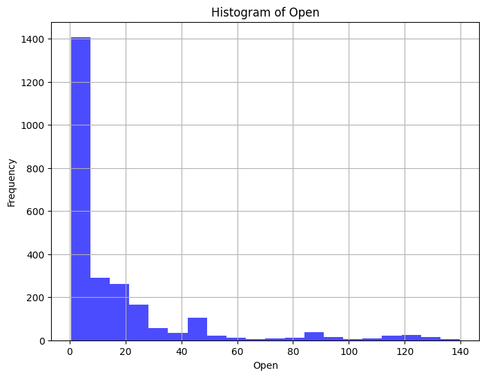

Skewed Right (Unimodal)

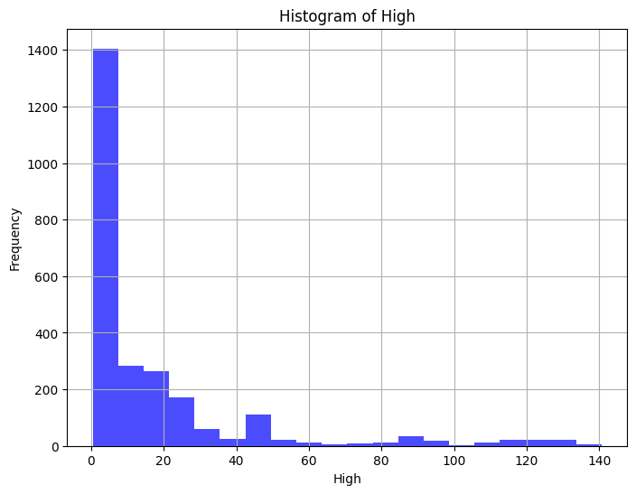

Skewed Right (Unimodal)

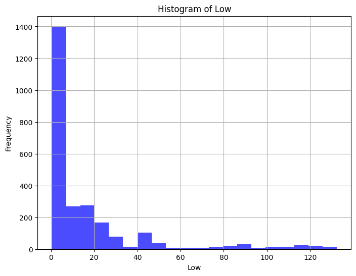

Skewed Right (Unimodal)

# 3 Identification of Data Quality Issues

Consider the missing values, irregular cardinality problems, and outliers. Summarize the **data quality issues** using a three-column table. The first column is the feature name, the second column is the associated data quality issue, and the third column describes potential handling strategies.

[output not shown]

# 4 Scatterplot Matrix

Construct the **scatterplot matrix** for the continuous features and comment on what you observed.

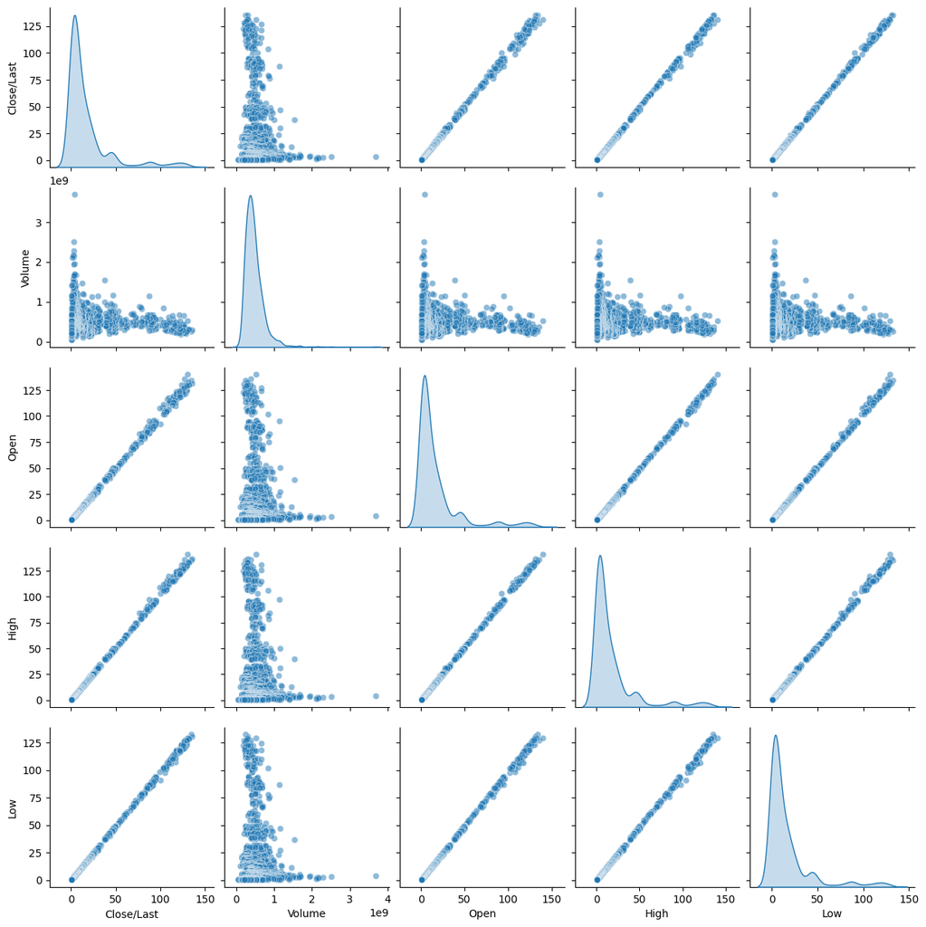

The scatterplot matrix shows a strong positive correlation between the price-related features (Close/Last, Open, High, Low), indicating that they move together in a linear fashion. Volume, on the other hand, does not exhibit any clear relationship with the price features, as seen by the dispersed points in the scatterplots. The distribution of Volume is right-skewed, indicating that most trading days have lower volumes with a few days showing very high volumes.

# 5 Visualizing Pairs of Categorical Features

Use multiple **barplot visualizations**.

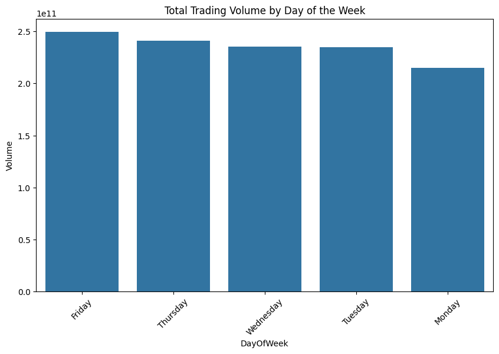

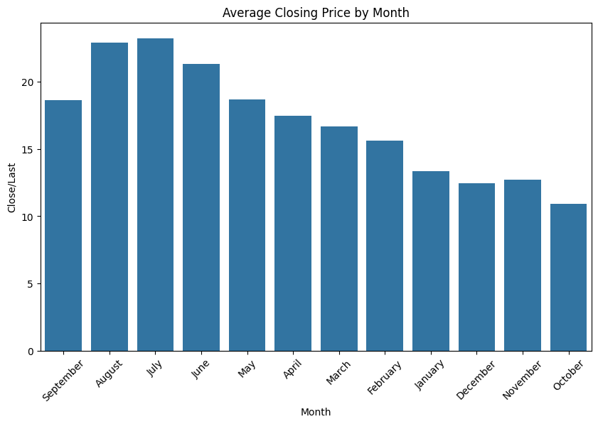

# 6 Visualizing Relationship Between a Catergorical and Continuous Feature

For a subset of the categorical and continuous features, perform **stacked barplot visualizations**. Comment on what you observed.

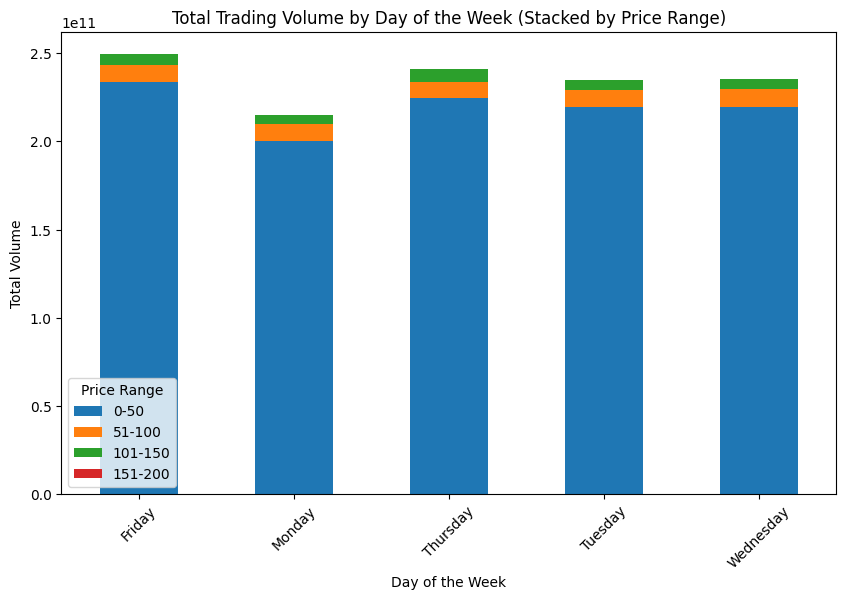

The stacked barplot shows total trading volume by day of the week, segmented by different price ranges. Friday exhibits the highest total trading volume, with the majority falling into the lower price range (0-50). All other days have relatively similar trading volumes, with Monday showing a slightly lower total volume compared to the other days. The higher price ranges (e.g., 101-150) contribute less to the overall volume compared to the lower price ranges across all days.

# 7 Boxplot Visualizations

For a subset of the categorical and continuous features, perform **boxplot visualizations**. Comment on what you observed.

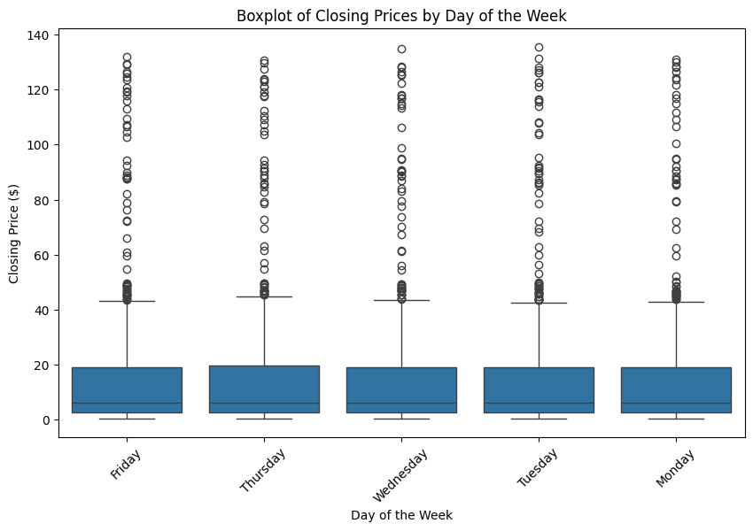

The boxplot shows the distribution of closing prices for each day of the week. Across all days, the median closing price remains fairly consistent, with most prices falling within the same range. However, there is a significant number of outliers (prices above $40), which is typical in stock market data due to price volatility. These outliers are present across all days, indicating that extreme price movements are not isolated to a specific day of the week. The interquartile range (IQR) is also similar for each day, indicating that the general spread of stock prices remains stable throughout the week.

# 8 Covariance Matrix

For the continuous features, construct the **covariance matrix**. Comment on what you observed.

|  | Close/Last | Volume | Open | High | Low |
| --- | --- | --- | --- | --- | --- |
| **Close/Last** | 6.676405e+02 | -2.717345e+08 | 6.678506e+02 | 6.811328e+02 | 6.529092e+02 |
| **Volume** | -2.717345e+08 | 6.381560e+16 | -2.675637e+08 | -2.585401e+08 | -2.800415e+08 |
| **Open** | 6.678506e+02 | -2.675637e+08 | 6.688159e+02 | 6.818036e+02 | 6.534324e+02 |
| **High** | 6.811328e+02 | -2.585401e+08 | 6.818036e+02 | 6.952984e+02 | 6.662445e+02 |
| **Low** | 6.529092e+02 | -2.800415e+08 | 6.534324e+02 | 6.662445e+02 | 6.387599e+02 |

# 9 Correlation Matrix

For the continuous features, construct the **correlation matrix**. Comment on what you observed.

|  | Close/Last | Volume | Open | High | Low |
| --- | --- | --- | --- | --- | --- |
| **Close/Last** | 1.000000 | -0.041630 | 0.999435 | 0.999712 | 0.999799 |
| **Volume** | -0.041630 | 1.000000 | -0.040955 | -0.038813 | -0.043862 |
| **Open** | 0.999435 | -0.040955 | 1.000000 | 0.999817 | 0.999720 |
| **High** | 0.999712 | -0.038813 | 0.999817 | 1.000000 | 0.999722 |
| **Low** | 0.999799 | -0.043862 | 0.999720 | 0.999722 | 1.000000 |

# 10 Range Normalization

List the continuous features that require **range normalization**. What is the rationale for your selection? Perform the range normalization and show the values before and after the normalization.

Before Normalization:

| Close/Last | Volume | Open | High | Low |
| --- | --- | --- | --- | --- |
| 116.00 | 382462400 | 117.06 | 118.6181 | 115.3901 |
| 117.87 | 293506400 | 117.35 | 119.6600 | 117.2500 |
| 113.37 | 310318900 | 115.89 | 117.7000 | 113.2200 |
| 115.59 | 231925900 | 118.17 | 118.8000 | 114.8300 |
| 116.78 | 248772300 | 116.79 | 118.1800 | 114.3600 |

After Normalization:

| Close/Last | Volume | Open | High | Low |
| --- | --- | --- | --- | --- |
| 0.855135 | 0.092469 | 0.836845 | 0.842213 | 0.870986 |
| 0.868970 | 0.068047 | 0.838926 | 0.849637 | 0.885076 |
| 0.835677 | 0.072663 | 0.828451 | 0.835670 | 0.854546 |
| 0.852102 | 0.051141 | 0.844809 | 0.843509 | 0.866743 |
| 0.860906 | 0.055766 | 0.834908 | 0.839091 | 0.863183 |

# 11 Binning

Do you see the need for converting a subset of the continuous features into categorical features? Select two such continuous features and convert the first into a categorical feature using the **equal-width binning*** and the second using **equal-frequency binning**. Show the feature values after the equal-width and equal-frequency binning.

Original and Equal-width Binned ‘Close/Last’:

| Close/Last | Close/Last_Binned_Equal_Width |
| --- | --- |
| 116.00 | Very High |
| 117.87 | Very High |
| 113.37 | Very High |
| 115.59 | Very High |
| 116.78 | Very High |

Original and Equal-frequency Binned ‘Volume’:

| Volume | Volume_Binned_Equal_Frequency |
| --- | --- |
| 382462400 | Medium |
| 293506400 | Low |
| 310318900 | Medium |
| 231925900 | Low |
| 248772300 | Low |

# 12 Undersampling

Do you see a need for undersampling? **Undersampling** is used to reduce the instances from the majority class so that the final dataset is balanced. For example, a binary classification problem has a target/outcome variable that takes two values, say, *approved* and *denied*. In the dataset, if 70% of the instances have the *approved* value for the target variable, the dataset is *imbalanced*. Ideally, the dataset should have approximately equal number of instances for each the values the target variable takes. [This](https://predictivehacks.com/undersampling-by-groups-in-r/) article illustrates the undersampling.

PriceChange Decrease 1373 Increase 1144 Name: count, dtype: int64

Since the difference between the two classes is not drastic. The imbalance ratio is about 55% to 45% which is relatively mild compared to highly imbalanced datasets where one class dominates the other example 80% vs 20%

# 13 Oversampling

**Oversampling** arises when we have too few instances from a class (called the minority class) relative to other classes. To boost the participation of the minority class in the (training) dataset, more observations from the minority class are generated usually by replicating the samples from the minority class.

In your dataset, do you see the need for oversampling? If so, which features require oversampling?

While there is an imbalance, it’s not severe. In scenarios where the imbalance is small like here, you could handle it by adjusting class weights in your model similar to the strategy for avoiding undersampling.

# 14 Summary

Summarize the findings you have discovered through the exploratory data analysis. The summary should about a page and should serve as an executive report for non-technical people.

In this analysis of stock market data, we observed that there is a mild class imbalance between price increases and decreases, with decreases slightly outnumbering increases. The price-related features show strong positive correlations, while trading volume has little correlation with price movements. Given the regulated nature of stock data, no significant data quality issues were detected, and strategies like adjusting class weights may be more appropriate than oversampling or undersampling to handle the small imbalance.